# Hello, my name is Alison

# Overview

You’ll use this document to build your first slide deck and render to HTML using the xaringan package 🎉.

You’ll use this deck to introduce yourself to another workshop participant. The chunk of R code above called setup is very important- please do not delete that or the YAML header above it either.

# Get started

- To make this document into a slide deck, update the output in the YAML to xaringan::moon_reader, instead of html_document.
- Save the current document.
- Click the **Knit** button. Your slides might show up in your RStudio Viewer Pane, or as a separate window.
  - If in the viewer pane, click on the window looking button to the right of the broom icon to see your slides in your normal browser.
  - If in a separate window, try clicking on the **Open in Browser** button to see in a larger window.
- Do you see two slides? If you do, look up and smile at Alison right now.

# Activate moon_reader

- Two ways to do this:
  - either use the RStudio Add-in and select Infinite Moon Reader (under XARINGAN)
  - or in your console type xaringan::infinite_moon_reader
- Again, open the rendered slides in a browser window. Now anytime you make changes to your .Rmd file and click **save**, xaringan will automatically regenerate your slides (you may need to click refresh in your browser).
- Insert your own name into the YAML title, and click **save**.
- Did your slides update with your name now on the title slide? If so, loop up and give Alison a thumbs up right now.

# Introduce yourself!

> My name is Alison and I am a Data Scientist & Professional Educator at RStudio. I live in Portland, Oregon with my husband, daughter, and our sourdough starter.

# Find me at…

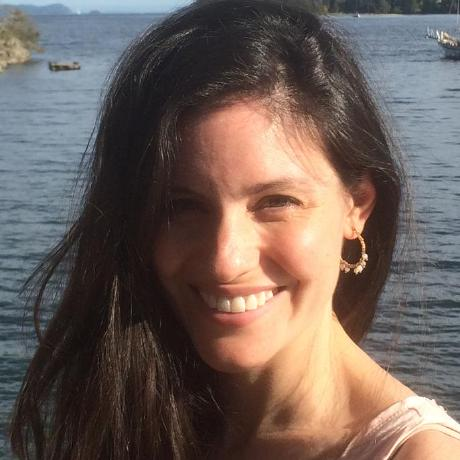

apreshill  
apreshill  
alison.rbind.io  
alison@rstudio.com

# Hi there

My name is Alison

I like hot toddies

`#rdogladies`

and babies

# Hi there, take 2

# two columns

My parents tell me that Alison with one “l” was more popular in the 80s- was it?

```r
# getting the data
alison_data <- babynames %>%
  filter(name == "Alison" |
           name == "Allison") %>%
  filter(sex == "F")
```

# “Alison” vs. “Allison” popularity over time

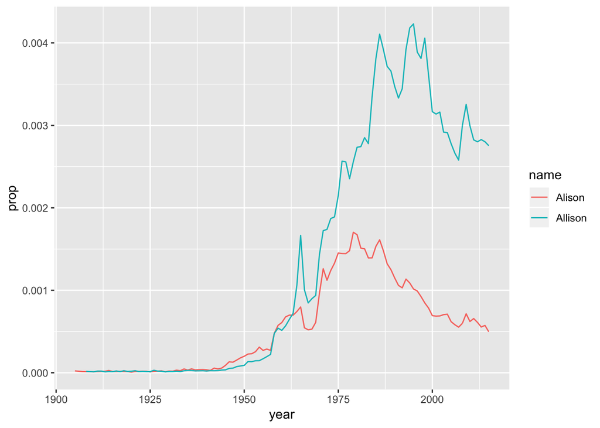

```r
# pull this code to print left
alison_plot <- ggplot(
  alison_data,
  aes(x = year,
      y = prop,
      group = name,
      color = name)) +
  geom_line()
```